2017 Edition

In this notebook, we will learn how to use the DataFrame API and SparkSQL to perform simple data analytics tasks.

# Goals

The main goals of this notebook are the following:

1. Understand the advantages and disadvantages of using DataFrame over RDD
2. Analyze the airline data with the DataFrame API and SparkSQL

# Steps

- First, in section 1, we will go through a short introduction about the DataFrame API with a small example to see how can we use it and how it compares to the low-level RDD abstraction.
- In section 2, we delve into the details of the use case of this notebook including: providing the context, introducing the data
- In section 3, we perform data exploration and analysis

# 1. RDD and DataFrame APIs

In our previous notebooks, we have worked with RDDs (Resilient Distributed Dataset), the basic abstraction in Spark. The main reason is due to the task at hand: we have been invovled in the design of distributed algorithms.

In this laboratory session, we study (or revisit) the DataFrame API - an immutable distributed collection of data. DataFrames allow developers to impose a **structure** on a distributed collection of data, allowing higher-level abstraction; in addition, DataFrames provide a domain specific language (DSL) API to manipulate distributed, structured data. Ultimately, the goal is to make Spark accessible to a wider audience, beyond researchers and specialized data engineers.

Let's take a small example to see the difference between RDDs and DataFrames. The two cells below contain short code snippets that perform the same task: count the frequency of words in a document, then sort the result in descending order. The first snippet is the same you have been working on in the very [first notebook](https://github.com/EURECOM-CLOUDS-COURSE/Introduction/blob/master/introduction-lab.ipynb) of the CLOUDS course. The second code snippet uses the DataFrame API.

```python
sc
```

**SparkContext**

[Spark UI](http://10.0.0.75:4040)

**Version**

`v2.2.0`

**Master**

`spark://spark-master0-7243-prod2:7077`

**AppName**

`pyspark-shell`

**Question 1.** Run both approaches (RDD and DataFrame) detailed below, compare their runtime, and discuss. Is the DataFrame API approach faster? Can you explain why?

```python
import time
time_start = time.time()
words = (
            # read the text file
            sc.textFile("/datasets/gutenberg/gutenberg_small.txt").repartition(16)

            # construct words from lines
            .flatMap(lambda line: line.split())

            # map each word to (word, 1)
            .map(lambda x: (x, 1))

            # reduce by key: accumulate sum the freq of the same word
            .reduceByKey(lambda freq1, freq2: freq1 + freq2)

            # swap (word, freq) to (freq, word)
            .map(lambda x: (x[1], x[0]))

            # sort result by key DESC
            .sortByKey(False)
         )
print("Runtime: {}s".format(time.time() - time_start))
print(words.take(5))
```

```
Runtime: 287.3209488391876s
[(29556020, 'the'), (18043957, 'of'), (14914748, 'and'), (12892052, 'to'), (9779124, 'a')]
```

```python
from pyspark.sql.types import *
from pyspark.sql import SQLContext
from pyspark.sql.functions import explode, split, desc
sqlContext = SQLContext(sc)
time_start = time.time()

# read the text file
df = sqlContext.read.text("/datasets/gutenberg/gutenberg_small.txt")

# show 3 samples
# df.show(3)

result = (
    # split into words
    df.select(explode(split(df.value, "\s+|\t+")).alias('word'))

    # group by each word
    .groupBy(['word'])

    # count the freq
    .count()

    # sort the result
    .orderBy(desc("count"))
)

result.show(5)
print("Runtime: {}s".format(time.time() - time_start))
```

```
+----+--------+
|word|   count|
+----+--------+
| the|29556020|
|  of|18043957|
|    |16611988|
| and|14914748|
|  to|12892052|
+----+--------+
only showing top 5 rows

Runtime: 97.17406463623047s
```

**Comments**: We can see that the DataFrame approach is much faster than the RDD approach (in our experiment is about 3 times). The reason for that is in general, in the DataFrame, we are optimizing in both physical plan and logical plan. Multiple physical plans are produced. The best physical plan will be choose base on its cost. On the other hand the RDD just has simple approach for optimization by combining the transformations which don't have the shuffle phase in between them into a single stage. That's the reasons why the DataFrame has the better performance than the RDD approach.

# 2. Analysis of flight data using the DataFrame API and SparkSQL

## Use case

In this notebook, we play the role of a data scientist working in the travel industry, specifically on air transportation of passengers. We want to explore the data collected by the Department of Transportation (DoT) to understand passengers' behavior, as well as the properties of all flights, across several airline companies.

The dataset provided by the DoT has 29 features, that can be either categorical or numerical. For example, the `src_airport` (source airport) is categorical: there exist no comparison operator between airport names. We can not say "SGN is bigger than NCE". The `departure_time` feature is numerical, for which a comparison operator exists. For instance, "flight departing before 6PM" can be express by "departure_time < 1800".

In this use case, most features are numerical, except carrier, flight_number, cancelled, cancelation_code and diverted. The data contains a header, that is useless when analyzing the data: it serves the purpose of an "embedded schema", to help data scientist figure out what information is available. Note that there are some features with missing values in some lines of the dataset. The missing values are marked by "NA". These values can cause problems when processing the data and can lead to unexpected results. Therefore, we need to remove the header and replace all "NA" values by empty values, such as they can be interpreted as null values.

## DataFrame

As we have seen already, there are multiple ways to manipulate data:

- Using the RDD abstraction
- Using the DataFrame abstraction.

A DataFrame is a distributed collection of data organized into named columns. It is based on the data frame concept in R language or in Pandas for Python. In some sense, it is similar to a table in a relational database: each item is a list of values (the columns). Also, the value in each row of each column can be accessed by the column's name.

To use DataFrames, the data should be clean (no invalid values). That means we cannot create DataFrame directly from the "RAW" data. Instead, we will first create an RDD from RAW data, produce a new, clean RDD, then transform it to a DataFrame and work on it. The RDD `cleaned_data` is an RDD[String]. We need to transform it to RDD[(TypeOfColumn1, TypeOfColumn2, ..., TypeOfColumn29)] then call a function to create a DataFrame from the new RDD. Please note that, package com.databricks.spark.csv can really help us to load the data efficiently without concerns about parsing, conversions, etc... However, the CSV package can have some problems when loading not well-formatted data or the data that has many kinds of missing values. The guidelines defined this notebook are a general way to help you work with any data.

DataFrames can be constructed from a wide array of sources such as: structured data files, tables in Hive, external databases, or existing RDDs.

During the labs in this course, we will mainly work with CSV data files. So, in the next sections, we only focus on constructing dataframes from structured data files directly and from existing RDD.

### Constructing a DataFrame directly from structured data file

To construct DataFrame from a structured file directly, the file type must be supported. Currently, Spark supports csv, json, avro and many more. Among these types, the csv type is one of the most popular in data analytics. A DataFrame is constructed from csv files by using the package spark-csv from Databricks.

```python
from pyspark.sql import SQLContext
from pyspark.sql.types import *

sqlContext = SQLContext(sc)

df = sqlContext.read.load('/datasets/airline/1994.csv',
    format='com.databricks.spark.csv',
    header='true',
    inferSchema='true',
    nullValue='NA'
)
```

Using the function load parametrized with `com.databricks.spark.csv`, we ask the SqlContext to use the parser from the DataBricks package. Additionally, we can specify whether the file has a header, or ask the parser to guess the data type of columns automatically. The parsed data types is viewed using the function printSchema.

```python
# print(df.dtypes)
df.printSchema()
```

```
root
 |-- Year: integer (nullable = true)
 |-- Month: integer (nullable = true)
 |-- DayofMonth: integer (nullable = true)
 |-- DayOfWeek: integer (nullable = true)
 |-- DepTime: integer (nullable = true)
 |-- CRSDepTime: integer (nullable = true)
 |-- ArrTime: integer (nullable = true)
 |-- CRSArrTime: integer (nullable = true)
 |-- UniqueCarrier: string (nullable = true)
 |-- FlightNum: integer (nullable = true)
 |-- TailNum: string (nullable = true)
 |-- ActualElapsedTime: integer (nullable = true)
 |-- CRSElapsedTime: integer (nullable = true)
 |-- AirTime: string (nullable = true)
 |-- ArrDelay: integer (nullable = true)
 |-- DepDelay: integer (nullable = true)
 |-- Origin: string (nullable = true)
 |-- Dest: string (nullable = true)
 |-- Distance: integer (nullable = true)
 |-- TaxiIn: string (nullable = true)
 |-- TaxiOut: string (nullable = true)
 |-- Cancelled: integer (nullable = true)
 |-- CancellationCode: string (nullable = true)
 |-- Diverted: integer (nullable = true)
 |-- CarrierDelay: string (nullable = true)
 |-- WeatherDelay: string (nullable = true)
 |-- NASDelay: string (nullable = true)
 |-- SecurityDelay: string (nullable = true)
 |-- LateAircraftDelay: string (nullable = true)
```

```python
df = (df
          # change type of column CRSDepTime by casting its values to interger type
          .withColumn('CRSDepTime', df.CRSDepTime.cast('int'))

          # rename the column
          .withColumnRenamed('CRSDepTime', 'scheduled_departure_time')
    )

# print schema of the current data
df.printSchema()

# run jobs to calculate basic statistic information and show it
df.describe().show()
```

```
root
 |-- Year: integer (nullable = true)
 |-- Month: integer (nullable = true)
 |-- DayofMonth: integer (nullable = true)
 |-- DayOfWeek: integer (nullable = true)
 |-- DepTime: integer (nullable = true)
 |-- scheduled_departure_time: integer (nullable = true)
 |-- ArrTime: integer (nullable = true)
 |-- CRSArrTime: integer (nullable = true)
 |-- UniqueCarrier: string (nullable = true)
 |-- FlightNum: integer (nullable = true)
 |-- TailNum: string (nullable = true)
 |-- ActualElapsedTime: integer (nullable = true)
 |-- CRSElapsedTime: integer (nullable = true)
 |-- AirTime: string (nullable = true)
 |-- ArrDelay: integer (nullable = true)
 |-- DepDelay: integer (nullable = true)
 |-- Origin: string (nullable = true)
 |-- Dest: string (nullable = true)
 |-- Distance: integer (nullable = true)
 |-- TaxiIn: string (nullable = true)
 |-- TaxiOut: string (nullable = true)
 |-- Cancelled: integer (nullable = true)
 |-- CancellationCode: string (nullable = true)
 |-- Diverted: integer (nullable = true)
 |-- CarrierDelay: string (nullable = true)
 |-- WeatherDelay: string (nullable = true)
 |-- NASDelay: string (nullable = true)
 |-- SecurityDelay: string (nullable = true)
 |-- LateAircraftDelay: string (nullable = true)

+-------+--------------------+------------------+------------------+------------------+------------------+------------------------+------------------+-----------------+-------------+-----------------+-------+------------------+------------------+-------+-----------------+-----------------+-------+--…
|summary|                Year|             Month|        DayofMonth|         DayOfWeek|           DepTime|scheduled_departure_time|           ArrTime|       CRSArrTime|UniqueCarrier|        FlightNum|TailNum| ActualElapsedTime|    CRSElapsedTime|AirTime|         ArrDelay|         DepDelay| Origin|  …
+-------+--------------------+------------------+------------------+------------------+------------------+------------------------+------------------+-----------------+-------------+-----------------+-------+------------------+------------------+-------+-----------------+-----------------+-------+--…
|  count|             5180048|           5180048|           5180048|           5180048|           5113308|                 5180048|           5101202|          5180048|      5180048|          5180048|      0|           5101202|           5180048|      0|          5101202|          5113308|5180048|51…
|   mean|              1994.0| 6.579943853802127|15.723382486031017|3.9516016067804776| 1345.266130849149|      1338.6794068317513|1494.4365151585841|1495.874874904634|         null|920.2637743897354|   null|114.00258860558746|114.82526995888841|   null|5.662489742613603| 6.65992152242736|   null|  …
| stddev|7.992761522517662...|3.4367203739746874| 8.788272360339171|1.9902384397189954|470.22426611386055|        463.617501147721|483.98495590427785|472.6701494862189|         null| 608.134294392797|   null| 64.88861058427636| 64.20406191593854|   null|23.61815604081699|22.22629770848844|   null|  …
|    min|                1994|                 1|                 1|                 1|                 1|                       1|                 1|                1|           AA|                1|   null|               -40|                -5|   null|             -115|             -109|    ABE|  …
|    max|                1994|                12|                31|                 7|              2400|                    2400|              2400|             2400|           WN|             3599|   null|               740|               578|   null|             1313|             1439|    YAK|  …
+-------+--------------------+------------------+------------------+------------------+------------------+------------------------+------------------+-----------------+-------------+-----------------+-------+------------------+------------------+-------+-----------------+-----------------+-------+--…
```

### Constructing a DataFrame from an existing RDD

Another way to construct a DataFrame is using data from an existing RDD. The main advantage of this approach is that it does not need a third party library. However, with this method, we have to remove the header ourself and provide a clear schema.

```python
from pyspark.sql import SQLContext
from pyspark.sql.types import *
from pyspark.sql.functions import explode, split, desc, col, udf, round
%matplotlib inline
import matplotlib.pyplot as plt
import matplotlib.colors as mcolors
import pandas as pd
import numpy as np
import pyspark.sql.functions as func
import matplotlib.patches as mpatches
import seaborn as sns

sqlContext = SQLContext(sc)

data = sc.textFile('/datasets/airline/1994.csv')

# extract the header
header = data.first()


# replace invalid data with NULL and remove header
cleaned_data = (
        data

        # filter out the header
        .filter(lambda line: line != header)

         # replace the 'missing data' by empty value
        .map(lambda line: ','.join(list(map(lambda x: x if x != 'NA' else '',line.split(',')))))
    )

airline_data_schema = StructType([ \
    #StructField( name, dataType, nullable)
    StructField("year",                     IntegerType(), True), \
    StructField("month",                    IntegerType(), True), \
    StructField("day_of_month",             IntegerType(), True), \
    StructField("day_of_week",              IntegerType(), True), \
    StructField("departure_time",           IntegerType(), True), \
    StructField("scheduled_departure_time", IntegerType(), True), \
    StructField("arrival_time",             IntegerType(), True), \
    StructField("scheduled_arrival_time",   IntegerType(), True), \
    StructField("carrier",                  StringType(),  True), \
    StructField("flight_number",            StringType(),  True), \
    StructField("tail_number",              StringType(), True), \
    StructField("actual_elapsed_time",      IntegerType(), True), \
    StructField("scheduled_elapsed_time",   IntegerType(), True), \
    StructField("air_time",                 IntegerType(), True), \
    StructField("arrival_delay",            IntegerType(), True), \
    StructField("departure_delay",          IntegerType(), True), \
    StructField("src_airport",              StringType(),  True), \
    StructField("dest_airport",             StringType(),  True), \
    StructField("distance",                 IntegerType(), True), \
    StructField("taxi_in_time",             IntegerType(), True), \
    StructField("taxi_out_time",            IntegerType(), True), \
    StructField("cancelled",                StringType(),  True), \
    StructField("cancellation_code",        StringType(),  True), \
    StructField("diverted",                 StringType(),  True), \
    StructField("carrier_delay",            IntegerType(), True), \
    StructField("weather_delay",            IntegerType(), True), \
    StructField("nas_delay",                IntegerType(), True), \
    StructField("security_delay",           IntegerType(), True), \
    StructField("late_aircraft_delay",      IntegerType(), True)\
])
```

```python
# convert each line into a tuple of features (columns) with the corresponding data type
cleaned_data_to_columns = (
    cleaned_data.map(lambda l: l.split(","))
    .map(lambda cols:
         (
            int(cols[0])  if cols[0] else None,
            int(cols[1])  if cols[1] else None,
            int(cols[2])  if cols[2] else None,
            int(cols[3])  if cols[3] else None,
            int(cols[4])  if cols[4] else None,
            int(cols[5])  if cols[5] else None,
            int(cols[6])  if cols[6] else None,
            int(cols[7])  if cols[7] else None,
            cols[8]       if cols[8] else None,
            cols[9]       if cols[9] else None,
            cols[10]      if cols[10] else None,
            int(cols[11]) if cols[11] else None,
            int(cols[12]) if cols[12] else None,
            int(cols[13]) if cols[13] else None,
            int(cols[14]) if cols[14] else None,
            int(cols[15]) if cols[15] else None,
            cols[16]      if cols[16] else None,
            cols[17]      if cols[17] else None,
            int(cols[18]) if cols[18] else None,
            int(cols[19]) if cols[19] else None,
            int(cols[20]) if cols[20] else None,
            cols[21]      if cols[21] else None,
            cols[22]      if cols[22] else None,
            cols[23]      if cols[23] else None,
            int(cols[24]) if cols[24] else None,
            int(cols[25]) if cols[25] else None,
            int(cols[26]) if cols[26] else None,
            int(cols[27]) if cols[27] else None,
            int(cols[28]) if cols[28] else None
         ))
)

# create dataframe
df = sqlContext.createDataFrame(cleaned_data_to_columns, airline_data_schema)\
    .select(['year', 'month', 'day_of_month', 'day_of_week',
            'scheduled_departure_time','scheduled_arrival_time',
            'arrival_delay', 'distance',
            'src_airport', 'dest_airport', 'carrier'])\
    .cache()
```

```python
# print schema of the current data
df.printSchema()
```

```
root
 |-- year: integer (nullable = true)
 |-- month: integer (nullable = true)
 |-- day_of_month: integer (nullable = true)
 |-- day_of_week: integer (nullable = true)
 |-- scheduled_departure_time: integer (nullable = true)
 |-- scheduled_arrival_time: integer (nullable = true)
 |-- arrival_delay: integer (nullable = true)
 |-- distance: integer (nullable = true)
 |-- src_airport: string (nullable = true)
 |-- dest_airport: string (nullable = true)
 |-- carrier: string (nullable = true)
```

### Examples

Using the contructed DataFrame, we can answer some simple questions:

- How many night flights do we have in our data?
- How many night flights per unique carrier?

**NOTE:** We define "night" to start at 6pm.

**Count total of flights**

```python
print("Total of flights: ")
df.count()
```

```
Total of flights:
```

```
5180048
```

**Count total of night flights**

```python
print("Total of night flights: ")
df[df.scheduled_departure_time > 1800].count()
```

```
Total of night flights:
```

```
1078203
```

**Count night flights per unique carrier**

```python
print("Night flights per unique carrier: ")
df[df.scheduled_departure_time > 1800].groupBy(df.carrier).count().orderBy('count', ascending=0).show()
```

```
Night flights per unique carrier:
+-------+------+
|carrier| count|
+-------+------+
|     DL|208224|
|     US|170397|
|     AA|142832|
|     WN|124024|
|     UA|113640|
|     NW|100453|
|     CO| 94501|
|     TW| 54771|
|     HP| 44351|
|     AS| 25010|
+-------+------+
```

# 3. Data exploration

Next, we will go over a series of simple queries on our data, to perform exploration and compute statistics using the DataFrame API and SparkSQL. These queries directly map to the questions you need to answer.

**NOTE:** finding the right question to ask is difficult! Don't be afraid to complement the questions below, with your own questions that, in your opinion, are valuable ways to inspect data. This can give you extra points!

- Basic queries:
  - How many unique origin airports?
  - How many unique destination airports?
  - How many carriers?
  - How many flights that have a scheduled departure time later than 18h00?
- Statistics on flight volume: this kind of statistics are helpful to reason about delays. Indeed, it is plausible to assume that "*the more flights in an airport, the higher the probability of delay*".
  - How many flights in each month of the year?
  - Is there any relationship between the number of flights and the days of week?
  - How many flights in different days of months and in different hours of days?
  - Which are the top 20 busiest airports (this depends on inbound and outbound traffic)?
  - Which are the top 20 busiest carriers?
- Statistics on the fraction of delayed flights
  - What is the percentage of delayed flights (over total flights) for different hours of the day?
  - Which hours of the day are characterized by the longest flight delay?
  - What are the fluctuation of the percentage of delayed flights over different time granularities?
  - What is the percentage of delayed flights which depart from one of the top 20 busiest airports?
  - What is the percentage of delayed flights which belong to one of the top 20 busiest carriers?

## Question 2: Basic queries

### Question 2.1

How many origin airports? How many destination airports? Discuss the results, indicating any discrepancies or strange facts about the data.

**Number of unique origin airports**

```python
print("Number of unique origin airports: ")
df.groupBy(df.src_airport).count().count()
```

```
Number of unique origin airports:
```

```
224
```

**Number of unique dest airports**

```python
print("Number of unique destination airports: ")
df.groupBy(df.dest_airport).count().count()
```

```
Number of unique destination airports:
```

```
225
```

**Comment:**

- Suprisingly, number of unique origin airports is different from number of unique dest airports (224 vs. 225), which means there exists at least one airports that is source airport, not dest airport and also, there exists at least one airports that is dest airport, not source airport, in dataset 1994.

### Question 2.2

How many unique carriers are present in the data?

**Number of unique carriers**

```python
print("Number of unique carriers: ")
df.groupBy(df.carrier).count().count()
```

```
Number of unique carriers:
```

```
10
```

### Question 2.3

- How many night flights (that is, flights departing later than 6pm or earlier than 6am)?
- What is the percentage of night flights over the total volume of flights

**NOTE:** Here we're using a more refined definition of what is a night flight, than in our earlier examples.

**Number of night flights**

```python
print("Number of night flights: ")
df[(df.scheduled_departure_time > 1800) | (df.scheduled_departure_time < 600)].count()
```

```
Number of night flights:
```

```
1121918
```

**Percentage of night flights over the total volumne of flights**

```python
print("Percentage of night flights over the total volumne of flights :")
df[(df.scheduled_departure_time > 1800) | (df.scheduled_departure_time < 600)].count()/(1.0*df.count())
```

```
Percentage of night flights over the total volumne of flights :
```

```
0.21658447952605844
```

## Question 3: Flight volume statistics

### Question 3.1:

How many flights in each month of the year? Plot the changes over months by a line chart and comment the figure.  
From the result, we can learn the dynamics of flight volume over months. For example, if we only consider flights in 1994 (to start, it's always better to focus on smaller amount of data), we can discuss about which months are most likely to have flights experiencing delays.

**Flights in each month**

```python
print("Flights per month :")
flight_per_month = df.groupBy(df.month).count().orderBy('month', ascending=1)
flight_per_month.show()
flight_per_month = flight_per_month.collect()
```

```
Flights per month :
+-----+------+
|month| count|
+-----+------+
|    1|423861|
|    2|386954|
|    3|435516|
|    4|420995|
|    5|436432|
|    6|426490|
|    7|443736|
|    8|451086|
|    9|430861|
|   10|449369|
|   11|428227|
|   12|446521|
+-----+------+
```

**Plot the changes over months**

```python
import matplotlib.pyplot as plt
```

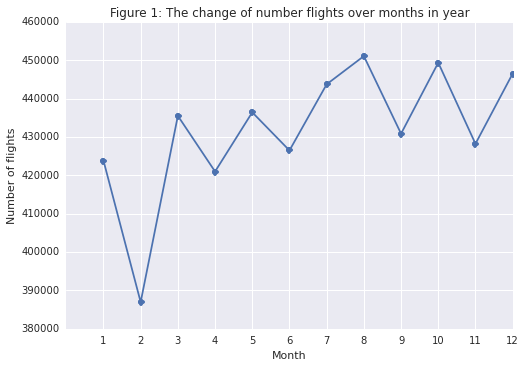

```python
plt.plot([x[0] for x in flight_per_month], [x[1] for x in flight_per_month], marker='o')
plt.xticks([x[0] for x in flight_per_month])
plt.title('Figure 1: The change of number flights over months in year')
plt.xlabel("Month")
plt.ylabel("Number of flights")
```

**Comment:**

- There is a significant change in the number of flights over month 1, 2 and 3, where month 2's flights is much smaller than month 1, 3's one.
- Number of flights in summer (month 7, 8) and winter (12, 1) seems to be high. Thus, these months are expected to have flights experiencing delays.

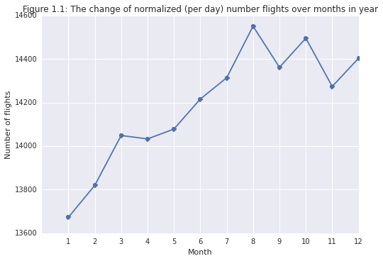

```python
nb_days_of_mnth = [31, 28, 31, 30, 31,30, 31, 31, 30, 31, 30, 31]
normalize_flight_per_month = [flight_per_month[i][1]/nb_days_of_mnth[i] for i in range(len(flight_per_month))]
plt.plot([x[0] for x in flight_per_month], normalize_flight_per_month, marker='o')
plt.xticks([x[0] for x in flight_per_month])
plt.title('Figure 1.1: The change of normalized (per day) number flights over months in year')
plt.xlabel("Month")
plt.ylabel("Number of flights")
```

**Comments:** In this question, since the day of each month is different, we would like to discover if it could be a factor to contributed to the different number of flights for each month. So we normalized it by day of each month in 1994. The result shows that the number of flights per day increasing gradually in the first half of the year, which is different with our observation in figure 1, specially if you look at February. The last half of year is almost matching with Figure 1 since August still is the most busy month of year

### Question 3.2:

Is there any relationship between the number of flights and the days of the week? Plot a bar chart and interpret the figure.  
**NOTE:** You should study both global aggregates (irrespectively of the month of the year), and monthly aggregates (day statistics, for each different month of the year).  
By answering this question, we could learn about the importance of the weekend/weekday feature for our predictive task.

```python
global_flight_day_of_week = df.groupBy(df.day_of_week).count().orderBy('day_of_week', ascending=1).collect()
```

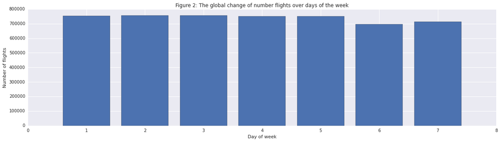

```python
plt.bar([x[0] for x in global_flight_day_of_week], [x[1] for x in global_flight_day_of_week], align='center')
plt.title('Figure 2: The global change of number flights over days of the week')
plt.xlabel("Day of week")
plt.ylabel("Number of flights")
```

**Comment:**

- In general, number of flights in the weekend is smaller than weekday.
- In global view, we see an equal number of flights for each weekday, which can not expose any meaningful statistical inference.

```python
monthly_flight_day_of_week = df.groupBy([df.month, df.day_of_week]).count().orderBy('month', ascending=1).collect()
```

```python
flight_tmp = [[x[0], x[1], x[2]] for x in monthly_flight_day_of_week]
flight_tmp = np.array(flight_tmp)
```

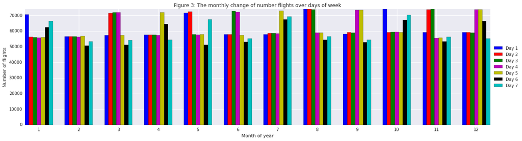

```python
fig_size = plt.rcParams["figure.figsize"]
fig_size[0] = 20
fig_size[1] = 5
plt.rcParams["figure.figsize"] = fig_size

mth = np.sort(np.unique(flight_tmp[:,0]))
day_of_week = np.sort(np.unique(flight_tmp[:,1]))
colors = ['b', 'r', 'g', 'm', 'y', 'k', 'c']
ax = plt.subplot(111)
for i_d in day_of_week:
    ax.bar(flight_tmp[flight_tmp[:,1] == i_d][:,0]+(i_d-4)*0.1, flight_tmp[flight_tmp[:,1] == i_d][:,2],width=0.1,color=colors[i_d-1],align='center', label = 'Day ' + str(i_d))

ax.legend(loc='center left', bbox_to_anchor=(1, 0.5))
ax.autoscale(tight=True)
plt.xticks(mth)
plt.title('Figure 3: The monthly change of number flights over days of week')
plt.xlabel("Month of year")
plt.ylabel("Number of flights")
plt.show()
```

**Comment:**

- It is hard to see any pattern from this figure. We couldn't find the same pattern for every month. To interpret this figure, we think it's better to see the habit of customer. For example, when is the most busy moment of the year when everyone go to vacations/holidays and the carriers change it accordingly to serve the most customer as possible and save the cost of operation.
- If we look at August, we see that, there are more flights at the beginning of week. It seems to be more people start their vacation at that time. In December, there are more flight on the Day 4 and Day 5. A fact is that 22 December 1994 is Thursday.
- In February, there maybe is less number of customers so we see the least number of flights on this month. We could guess that everyone now come back to work, study after holidays.

### Question 3.3

How many flights in different days of months and in different hours of days?  
**NOTE:** Similarly to the previous note, you need to compute both global statistcs and monthly statistics.  
Plot bar charts, and interpret your figures.

**Flights in different days of months**

```python
global_flight_day_of_month = df.groupBy(df.day_of_month).count().orderBy('day_of_month', ascending=1).collect()
```

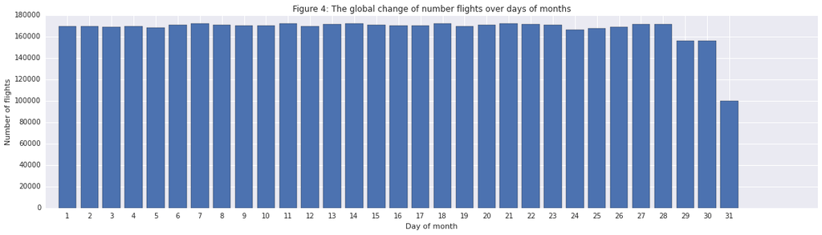

```python
plt.bar([x[0] for x in global_flight_day_of_month], [x[1] for x in global_flight_day_of_month], align='center')
plt.title('Figure 4: The global change of number flights over days of months')
plt.xticks([x[0] for x in global_flight_day_of_month])
plt.xlabel("Day of month")
plt.ylabel("Number of flights")
```

**Comment:**

- Interestingly, the number of flights at end of a month is significantly smaller than others
- The global change does not make sense in local evaluation of monthly change of flights.

```python
monthly_flight_day_of_month = df.groupBy([df.month, df.day_of_month]).count().orderBy('month', ascending=1).collect()
```

```python
flight_tmp = [[x[0], x[1], x[2]] for x in monthly_flight_day_of_month]
flight_tmp = np.array(flight_tmp)
```

```python
print("Maximum flight of a day: ")
max_day = np.max(flight_tmp[:,2])
print(max_day)
print("Minimum flight of a day: ")
min_day = np.min(flight_tmp[:,2])
print(min_day)
```

```
Maximum flight of a day:
15011
Minimum flight of a day:
11521
```

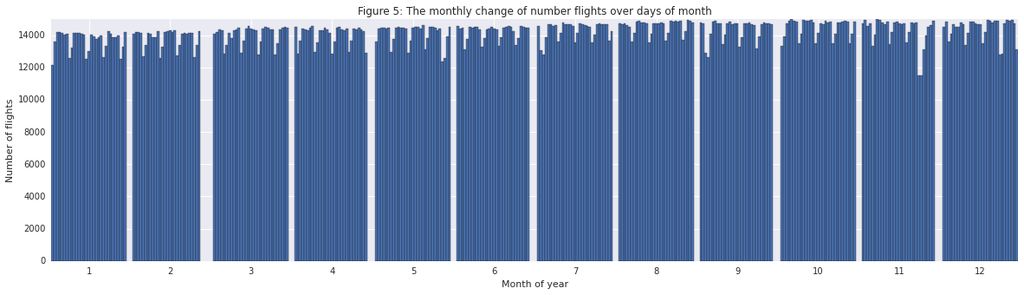

```python
fig_size = plt.rcParams["figure.figsize"]
fig_size[0] = 20
fig_size[1] = 5
plt.rcParams["figure.figsize"] = fig_size

mth = np.sort(np.unique(flight_tmp[:,0]))
day_of_month = np.sort(np.unique(flight_tmp[:,1]))
ax = plt.subplot(111)
for i_d in day_of_month:
    ax.bar(flight_tmp[flight_tmp[:,1] == i_d][:,0]+(i_d-16)*0.03, flight_tmp[flight_tmp[:,1] == i_d][:,2], width=0.03,align='center')

ax.legend(loc='center left', bbox_to_anchor=(1, 0.5))
ax.autoscale(tight=True)
plt.xticks(mth)
plt.title('Figure 5: The monthly change of number flights over days of month')
plt.xlabel("Month of year")
plt.ylabel("Number of flights")
plt.show()
```

**Comment:**

- We could see the pattern of almost every months (for a week). Of course there are exceptions such as some days at almost the end of November, there are significant reduction of number of flight at those days compare with other days in the year.

**Flights in different hours of days**

```python
from pyspark.sql.functions import udf
def convert_hour(x):
    if (x // 100 == 24):
        return  0
    else:
        return x//100
convert_hour_udf = udf(convert_hour, IntegerType())
```

```python
global_flight_hour_of_day_tmp = df.withColumn("hour_of_day",convert_hour_udf(df.scheduled_departure_time))
global_flight_hour_of_day = global_flight_hour_of_day_tmp.groupBy("hour_of_day").count().orderBy("hour_of_day", ascending=1).collect()
```

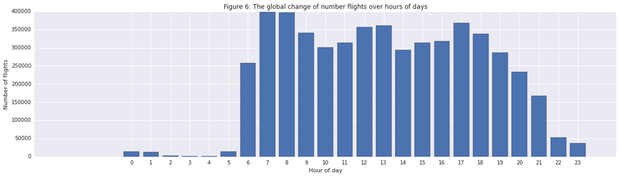

```python
plt.bar([x[0] for x in global_flight_hour_of_day], [x[1] for x in global_flight_hour_of_day], align='center')
plt.xticks([x[0] for x in global_flight_hour_of_day])
plt.title('Figure 6: The global change of number flights over hours of days')
plt.xlabel("Hour of day")
plt.ylabel("Number of flights")
```

**Comment:**

- From the data, we could see that the number of flights will depends also which is the departure time. We see much less flights around 10PM to 5AM. The mot busy moment of the day is around 7AM to 9AM. It goes up and down a bit around the day. From 6PM, the number of flights reduces over time.

```python
monthly_flight_hour_of_day = global_flight_hour_of_day_tmp.groupBy([df.month,"hour_of_day"]).count().orderBy(df.month, ascending=1).collect()
```

```python
flight_tmp = [[x[0], x[1], x[2]] for x in monthly_flight_hour_of_day]
flight_tmp = np.array(flight_tmp)
```

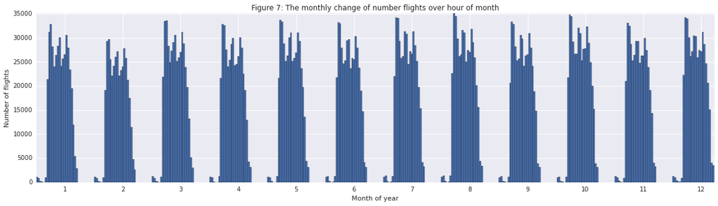

```python
fig_size = plt.rcParams["figure.figsize"]
fig_size[0] = 20
fig_size[1] = 5
plt.rcParams["figure.figsize"] = fig_size

mth = np.sort(np.unique(flight_tmp[:,0]))
hour_of_month = np.sort(np.unique(flight_tmp[:,1]))
ax = plt.subplot(111)
for i_d in hour_of_month:
    ax.bar(flight_tmp[flight_tmp[:,1] == i_d][:,0]+(i_d-16)*0.03, flight_tmp[flight_tmp[:,1] == i_d][:,2], width=0.03,align='center')

ax.legend(loc='center left', bbox_to_anchor=(1, 0.5))
ax.autoscale(tight=True)
plt.xticks(mth)
plt.title('Figure 7: The monthly change of number flights over hour of month')
plt.xlabel("Month of year")
plt.ylabel("Number of flights")
plt.show()
```

**Comment:**

- In this figure, we observe almost the same pattern with the firgure above it. We see that again, the number of flights is much less from 10 PM to 6AM. But we also see that the most busy hours (from 7AM to 9AM) changes at some months, for example at the "rush hour", it is even worse in August, October and December.

### Question 3.4

Which are the **top 20** busiest airports? Compute this in terms of the inbound, outbound and total number of flights.

```python
outbound =  df.groupBy(df.src_airport).count().select(col("src_airport").alias("airport"), col("count").alias("outbound"))
inbound = df.groupBy(df.dest_airport).count().select(col("dest_airport").alias("airport"), col("count").alias("inbound"))
busiest_airport = inbound.join(outbound,["airport"], "outer").select("airport", "inbound", "outbound").fillna({'outbound':0}).fillna({'inbound':0})
busiest_airport = busiest_airport.select("airport","inbound","outbound", (busiest_airport.outbound+busiest_airport.inbound).alias("Total")).orderBy("Total", ascending=0)
print("Top 20 busiest airports :")
busiest_airport.show()
busiest_airport = busiest_airport.head(20)
```

```
Top 20 busiest airports :
+-------+-------+--------+------+
|airport|inbound|outbound| Total|
+-------+-------+--------+------+
|    ORD| 283720|  277741|561461|
|    DFW| 260249|  256274|516523|
|    ATL| 221588|  221486|443074|
|    LAX| 152959|  153494|306453|
|    STL| 152800|  151609|304409|
|    DEN| 144099|  141427|285526|
|    PHX| 140979|  139581|280560|
|    DTW| 139435|  136837|276272|
|    PIT| 131962|  130977|262939|
|    CLT| 130321|  129391|259712|
|    MSP| 124758|  123222|247980|
|    SFO| 117245|  118233|235478|
|    EWR| 117223|  116768|233991|
|    IAH| 104409|  104182|208591|
|    LGA| 101498|  101864|203362|
|    BOS|  99331|  100365|199696|
|    LAS|  94948|   94972|189920|
|    PHL|  93312|   93585|186897|
|    DCA|  87670|   88445|176115|
|    MCO|  76600|   77120|153720|
+-------+-------+--------+------+
only showing top 20 rows
```

### Question 3.5

Which are the **top 20** busiest carriers? Compute this in terms of number of flights.

```python
busiest_carrier = df.groupby(df.carrier).count().orderBy("count", ascending=0)
print("Top 20 busiest carriers : ")
busiest_carrier.show()
busiest_carrier = busiest_carrier.head(20)
```

```
Top 20 busiest carriers :
+-------+------+
|carrier| count|
+-------+------+
|     DL|874526|
|     US|857906|
|     AA|722277|
|     UA|638750|
|     WN|565426|
|     CO|484834|
|     NW|482798|
|     TW|258205|
|     HP|177851|
|     AS|117475|
+-------+------+
```

**Note:** In this dataset, there are only 10 carriers.

## Question 4

In this series of questions we focus on the computation of statistics about the percentage of delayed flights.

### Question 4.1

What is the percentage of delayed flights for different hours of the day? Plot a bar chart and interpret the figure.

IMPORTANT!

A flight is considered as delayed if it's actual arrival time is more than 15 minutes later than the scheduled arrival time.

```python
delay_flight_hour_of_day = df[df.arrival_delay >= 15].withColumn("hour_of_day",convert_hour_udf(df.scheduled_departure_time))
delay_flight_hour_of_day = delay_flight_hour_of_day.groupBy("hour_of_day").count().orderBy("hour_of_day", ascending=1)
delay_flight_hour_of_day = delay_flight_hour_of_day.collect()
```

```python
hour_ = []
ratio_per_hour = []
for delay_ in delay_flight_hour_of_day:
    hour_.append(delay_[0])
    ratio_per_hour.append(delay_[1]/(1.0*global_flight_hour_of_day[delay_[0]][1]))
pdf_delay_ratio_per_hour = [hour_, ratio_per_hour]
```

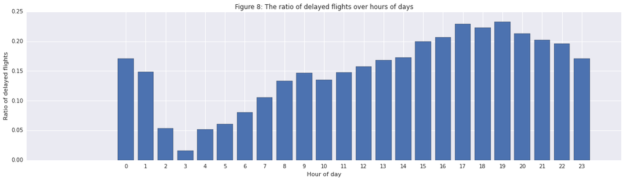

```python
plt.bar(pdf_delay_ratio_per_hour[0], pdf_delay_ratio_per_hour[1], align='center')
plt.xticks(pdf_delay_ratio_per_hour[0])
plt.title('Figure 8: The ratio of delayed flights over hours of days')
plt.xlabel("Hour of day")
plt.ylabel("Ratio of delayed flights")
```

### Question 4.2

You will realize that saying *"at 4 A.M. there is a very low chance of a flight being delayed"* is not giving you a full picture of the situation. Indeed, it might be true that there is very little probability for an early flight to be delayed, but if it does, the delay might be huge, like 6 hours!

Then, the question is: **which hours of the day are characterized by the largest mean delay?** (you can consider the median too) Plot a Bar chart and explain it.

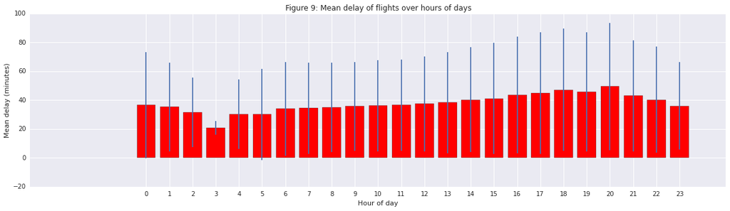

```python
mean_std_delay_flight_hour_of_day = df[df.arrival_delay >= 15].withColumn("hour_of_day",convert_hour_udf(df.scheduled_departure_time))
mean_delay_flight_hour_of_day  = mean_std_delay_flight_hour_of_day.groupBy("hour_of_day").agg((func.avg(df.arrival_delay)).alias('mean_delay')).orderBy("hour_of_day", ascending=1).collect()
std_delay_flight_hour_of_day  = mean_std_delay_flight_hour_of_day.groupBy("hour_of_day").agg((func.stddev(df.arrival_delay)).alias('std_delay')).orderBy("hour_of_day", ascending=1).collect()
hour_ = []
mean_per_hour = []
std_per_hour = []
for delay_ in mean_delay_flight_hour_of_day:
    hour_.append(delay_[0])
    mean_per_hour.append(delay_[1])
    for std_ in std_delay_flight_hour_of_day:
        if (delay_[0] == std_[0]):
            std_per_hour.append(std_[1])
            break

mean_delay_per_hour = [hour_, mean_per_hour, std_per_hour]
plt.bar(mean_delay_per_hour[0], mean_delay_per_hour[1], color = 'r', yerr = mean_delay_per_hour[2]  ,align='center')
plt.xticks(mean_delay_per_hour[0])
plt.title('Figure 9: Mean delay of flights over hours of days')
plt.xlabel("Hour of day")
plt.ylabel("Mean delay (minutes)")
```

**Comment:**

```
Std of delay at hour = 5:  31.6450927719
```

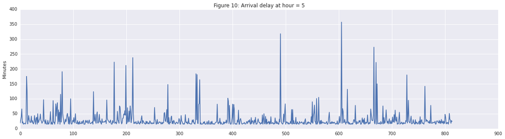

```python
x = df[df.arrival_delay >= 15].withColumn("hour_of_day",convert_hour_udf(df.scheduled_departure_time))
y = x[x["hour_of_day"] == 5].select("arrival_delay").collect()
z = [y_[0] for y_ in y]
plt.plot(z)
plt.title("Figure 10: Arrival delay at hour = 5")
plt.ylabel("Minutes")
print("Std of delay at hour = 5: ", np.std(z))
```

So, an attentive student should notice here that we have somehow a problem with the definition of delay! Next, we will improve how to represent and visualize data to overcome this problem.

**NOTE**: the following piece of code assumes you correctly answered the previous questions. The naming convention of the DataFrames we use next should be clear enough for you to produce them by answering the questions above.

```python
mean_delay_flight_hour_of_day = df.withColumn("hour_of_day",convert_hour_udf(df.scheduled_departure_time))
mean_delay_flight_hour_of_day  = mean_delay_flight_hour_of_day.groupBy("hour_of_day").agg((func.sum(df.arrival_delay)/func.count('*')).alias('mean_delay')).orderBy("hour_of_day", ascending=1).collect()
hour_ = []
mean_delay_per_hour = []
for delay_ in mean_delay_flight_hour_of_day:
    hour_.append(delay_[0])
    mean_delay_per_hour.append(delay_[1])
pdf_mean_delay_per_hour = [hour_, mean_delay_per_hour]
```

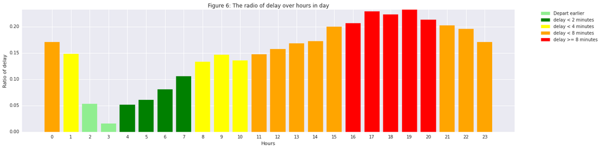

```python
#pdf2 = pd.DataFrame(data=mean_delay_per_hour.collect())
plt.xlabel("Hours")
plt.ylabel("Ratio of delay")
plt.title('Figure 6: The radio of delay over hours in day')
plt.grid(True,which="both",ls="-")
bars = plt.bar(pdf_delay_ratio_per_hour[0], pdf_delay_ratio_per_hour[1], align='center', edgecolor = "black")
for i in range(0, len(bars)):
    color = 'red'
    if pdf_mean_delay_per_hour[1][i] < 0:
        color = 'lightgreen'
    elif pdf_mean_delay_per_hour[1][i] < 2:
        color = 'green'
    elif pdf_mean_delay_per_hour[1][i] < 4:
        color = 'yellow'
    elif pdf_mean_delay_per_hour[1][i] < 8:
        color = 'orange'

    bars[i].set_color(color)

patch1 = mpatches.Patch(color='lightgreen', label='Depart earlier')
patch2 = mpatches.Patch(color='green', label='delay < 2 minutes')
patch3 = mpatches.Patch(color='yellow', label='delay < 4 minutes')
patch4 = mpatches.Patch(color='orange', label='delay < 8 minutes')
patch5 = mpatches.Patch(color='red', label='delay >= 8 minutes')

plt.legend(handles=[patch1, patch2, patch3, patch4, patch5], bbox_to_anchor=(1.05, 1), loc=2, borderaxespad=0.)
plt.xticks(pdf_delay_ratio_per_hour[0])
plt.margins(0.05, 0)
plt.show()
```

This example shows us that the way representing results are also important.

### Question 4.3

Plot a bar chart to show the percentage of delayed flights over days in a month. Discuss your findings from the figure.

```python
delay_flight_day_of_month = df[df.arrival_delay >= 15].groupBy(df.day_of_month).count().orderBy('day_of_month', ascending=1).collect()
```

```python
day_ = []
ratio_per_day = []
for delay_ in delay_flight_day_of_month:
    day_.append(delay_[0])
    ratio_per_day.append(delay_[1]/(1.0*global_flight_day_of_month[delay_[0]-1][1]))
delay_ratio_day_of_month = [day_, ratio_per_day]
```

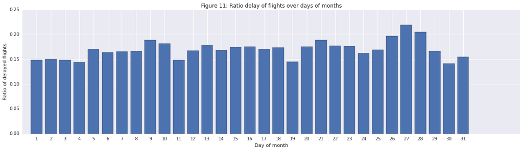

```python
plt.bar(delay_ratio_day_of_month[0], delay_ratio_day_of_month[1], align='center')
plt.xticks(delay_ratio_day_of_month[0])
plt.title('Figure 11: Ratio delay of flights over days of months')
plt.xlabel("Day of month")
plt.ylabel("Ratio of delayed flights")
```

**Comment:**

- The probability for a flight to be delayed is low at the beginning or at the very end of a given months

### Question 4.4

Plot a bar chart to show the percentage of delayed flights over days in a week. Discuss your findings from the figure.

```python
delay_flight_day_of_week = df[df.arrival_delay >= 15].groupBy(df.day_of_week).count().orderBy('day_of_week', ascending=1).collect()
```

```python
day_ = []
ratio_per_day = []
for delay_ in delay_flight_day_of_week:
    day_.append(delay_[0])
    ratio_per_day.append(delay_[1]/(1.0*global_flight_day_of_week[delay_[0]-1][1]))
delay_ratio_day_of_week = [day_, ratio_per_day]
```

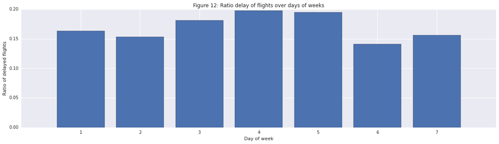

```python
plt.bar(delay_ratio_day_of_week[0], delay_ratio_day_of_week[1], align='center')
plt.xticks(delay_ratio_day_of_week[0])
plt.title('Figure 12: Ratio delay of flights over days of weeks')
plt.xlabel("Day of week")
plt.ylabel("Ratio of delayed flights")
```

**Comment:**

- Flights on two first weekdays and on the weekend, are less likely to be delayed. To avoid the delay, we should travel in those days.

### Question 4.5

Plot a bar chart to show the percentage of delayed flights over months in a year. Discuss your findings from the figure.

```python
delay_flight_month_of_year = df[df.arrival_delay >= 15].groupBy(df.month).count().orderBy('month', ascending=1).collect()
```

```python
month_ = []
ratio_per_month = []
for delay_ in delay_flight_month_of_year:
    month_.append(delay_[0])
    ratio_per_month.append(delay_[1]/(1.0*flight_per_month[delay_[0]-1][1]))
delay_ratio_month_of_year = [month_, ratio_per_month]
```

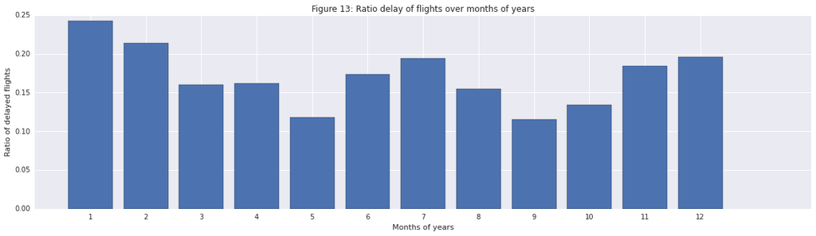

```python
plt.bar(delay_ratio_month_of_year[0], delay_ratio_month_of_year[1], align='center')
plt.xticks(delay_ratio_month_of_year[0])
plt.title('Figure 13: Ratio delay of flights over months of years')
plt.xlabel("Months of years")
plt.ylabel("Ratio of delayed flights")
```

**Comment:**

We are ready now to draw some observations from our data, even if we have only looked at data coming from a year worth of flights:

- The probability for a flight to be delayed is low at the beginning or at the very end of a given months
- Flights on two first weekdays and on the weekend, are less likely to be delayed
- May and September are very good months for travelling, as the probability of delay is low (remember we're working on US data. Do you think this is also true in France?)

Putting things together, we can have a global picture of the whole year!

```python
from pyspark.sql.functions import when
df_with_delay = df.withColumn('is_delay', when(df["arrival_delay"] >= 15, 1).otherwise(0))
statistic_day = df_with_delay.groupBy(['year','month', 'day_of_month', 'day_of_week'])\
    .agg((func.sum('is_delay')/func.count('*')).alias('delay_ratio'))

# assume that we do statistic on year 1994
statistic_day = statistic_day\
    .orderBy('year', 'month', 'day_of_month', 'day_of_week')
pdf = pd.DataFrame(data=statistic_day.collect())
```

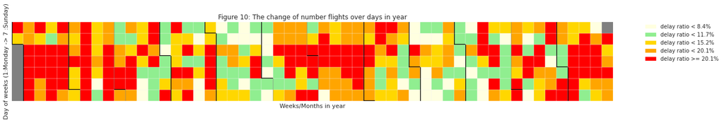

```python
fig = plt.figure(figsize=(20,10))
ax = fig.add_subplot(1,1,1)
plt.xlabel("Weeks/Months in year")
plt.ylabel("Day of weeks (1:Monday -> 7 :Sunday)")
plt.title('Figure 10: The change of number flights over days in year')

rec_size = 0.3
from matplotlib.patches import Rectangle
import datetime
num_days = len(pdf[0])
ax.patch.set_facecolor('gray')
ax.set_aspect('equal', 'box')
ax.xaxis.set_major_locator(plt.NullLocator())
ax.yaxis.set_major_locator(plt.NullLocator())

for i in range(0, num_days):
    # extract information from the result
    year = pdf[0][i]
    month = pdf[1][i]
    day_of_month = pdf[2][i]
    day_of_week = pdf[3][i]
    day_of_year= datetime.date(year=year, month=month, day=day_of_month).timetuple()
    week_of_year = datetime.date(year=year, month=month, day=day_of_month).isocalendar()[1]

    # dealing with the week of the previous year
    if week_of_year == 52 and month == 1:
        week_of_year = 0

    # the coordinate of a day in graph
    X = week_of_year*rec_size
    Y = day_of_week*rec_size

    # use different colors to show the delay ratio
    color = 'white'
    if pdf[4][i] <= 0.084:
        color = 'lightyellow'
    elif pdf[4][i] <= 0.117:
        color = 'lightgreen'
    elif pdf[4][i] <= 0.152:
        color = 'gold'
    elif pdf[4][i] <= 0.201:
        color = 'orange'
    else:
        color = 'red'
    rect = plt.Rectangle((X - rec_size/2.0, Y - rec_size/2.0), rec_size, rec_size,
                      alpha=1, facecolor=color, edgecolor='whitesmoke')

    ax.add_patch(rect)

    # drawing boders to separate months
    if day_of_month <= 7:
        rect2 = plt.Rectangle((X -rec_size/2.0, Y - rec_size/2.0), 0.01, rec_size,
                      alpha=1, facecolor='black')
        ax.add_patch(rect2)
    if day_of_month == 1:
        rect2 = plt.Rectangle((X - rec_size/2.0, Y - rec_size/2.0), rec_size, 0.01,
                      alpha=1, facecolor='black')
        ax.add_patch(rect2)
ax.autoscale_view()

patch1 = mpatches.Patch(color='lightyellow', label='delay ratio < 8.4%')
patch2 = mpatches.Patch(color='lightgreen', label='delay ratio < 11.7%')
patch3 = mpatches.Patch(color='gold', label='delay ratio < 15.2%')
patch4 = mpatches.Patch(color='orange', label='delay ratio < 20.1%')
patch5 = mpatches.Patch(color='red', label='delay ratio >= 20.1%')

plt.legend(handles=[patch1, patch2, patch3, patch4, patch5], bbox_to_anchor=(1.05, 1), loc=2, borderaxespad=0.)

plt.show()
```

### Question 4.6

What is the delay probability for the top 20 busiest airports? By drawing the flight volume of each airport and the associated delay probability in a single plot, we can observe the relationship between airports, number of flights and the delay.

HINT

Function `.isin()` helps checking whether a value in column belongs to a list.

SUGGESTION

You can try with different chart type to have a better visualization.

**Notes:**

**In this lab, we assume that airport of a flight is its destination. Of course, some people could argue that the airport of flight is its src_aitport or some could say that it is both destination if you really what is the reason of delay. Because the arrival of delay is the consequences of many factors: delay of departure, the problem in the trajectory, or sometimes is the destination airport (busy taxi lane). So let's assume that the dest airport is the airport to simplify the problem.**

```python
airport_name = []
volume = []
for airport_ in busiest_airport:
    airport_name.append(airport_[0])
    volume.append(airport_[3])
volumne_busiest_airports = [airport_name, volume]
```

```python
delay_flight_airport = df[df.arrival_delay >= 15].groupBy(df.dest_airport).count()
delay_flight_airport = delay_flight_airport[delay_flight_airport.dest_airport.isin(volumne_busiest_airports[0])].collect()
delay_prob = []
for i in range(len(volumne_busiest_airports[0])):
    airport_name_ = volumne_busiest_airports[0][i]
    for airport_ in delay_flight_airport:
        if (airport_[0] == airport_name_):
            delay_prob.append(airport_[1]/(1.0*volumne_busiest_airports[1][i]))
            break;
volumne_busiest_airports.append(delay_prob)
```

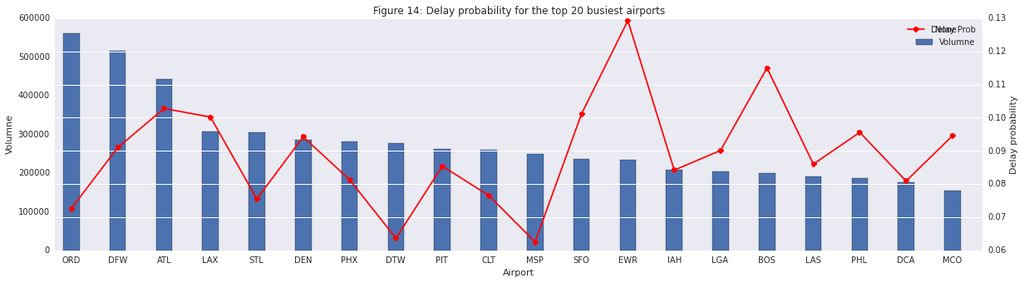

```python
import pandas as pd
airport_delay_prob = pd.DataFrame({
 'airport' : volumne_busiest_airports[0] ,
 'volumne' : volumne_busiest_airports[1],
 'delay_prob' : volumne_busiest_airports[2]})

ax1 = airport_delay_prob['volumne'].plot(kind='bar', width = 0.35, label='Volumne')
ax1.set_xlabel("Airport")
ax1.set_ylabel("Volumne")
ax1.legend()
ax2 = airport_delay_prob['delay_prob'].plot(secondary_y=True,color='r', marker='o', label = 'Delay Prob')
ax2.set_ylabel("Delay probability")
ax2.legend()
ax = plt.gca()
plt.xlim([-0.35, len(airport_delay_prob['airport'])-0.35])
ax.set_xticklabels(airport_delay_prob['airport'])
plt.title('Figure 14: Delay probability for the top 20 busiest airports')
plt.show()
```

**Comment:**

- Interestingly, we observe that, the ORD airport which serve the biggest volume of flight but it is one of airports which have the least probability of delay flight. It means that, the probability of delay depends also on the other factor (human, organisation, infrastructure, weather, position of airport,...) not only the volume. For example, if we look at the airport has the most probability of delay (EWR), it only serve about half of the number flight of ORD but the probability is 13% compare with ORD: about 7%. So if we would like to predict the chance of our flight could get delayed, simply looking at the volume of flights at that airport isn't enough.

### Question 4.7

What is the percentage of delayed flights which belong to one of the top 20 busiest carriers? Comment the figure!

SUGGESTION

You can try with different chart type to have a better visualization.

```python
carrier_name = []
volume = []
for carrier_ in busiest_carrier:
    carrier_name.append(carrier_[0])
    volume.append(carrier_[1])
volumne_busiest_carriers = [carrier_name, volume]
```

```python
delay_flight_carrier = df[df.arrival_delay >= 15].groupBy(df.carrier).count()
delay_flight_carrier = delay_flight_carrier[delay_flight_carrier.carrier.isin(volumne_busiest_carriers[0])].collect()

delay_prob = []
for i in range(len(volumne_busiest_carriers[0])):
    carrier_name_ = volumne_busiest_carriers[0][i]
    for carrier_ in delay_flight_carrier:
        if (carrier_[0] == carrier_name_):
            delay_prob.append(carrier_[1]/(1.0*volumne_busiest_carriers[1][i]))
            break;
volumne_busiest_carriers.append(delay_prob)
```

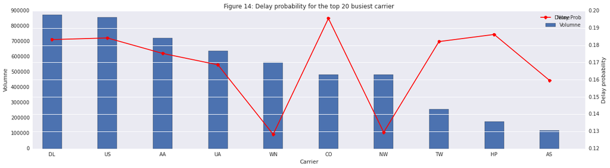

```python
import pandas as pd
carrier_delay_prob = pd.DataFrame({
 'carrier' : volumne_busiest_carriers[0] ,
 'volumne' : volumne_busiest_carriers[1],
 'delay_prob' : volumne_busiest_carriers[2]})

ax1 = carrier_delay_prob['volumne'].plot(kind='bar', width = 0.35, label='Volumne')
ax1.set_xlabel("Carrier")
ax1.set_ylabel("Volumne")
ax1.legend()
ax2 = carrier_delay_prob['delay_prob'].plot(secondary_y=True,color='r', marker='o', label = 'Delay Prob')
ax2.set_ylabel("Delay probability")
ax2.legend()
ax = plt.gca()
plt.xlim([-0.35, len(carrier_delay_prob['carrier'])-0.35])
ax.set_xticklabels(carrier_delay_prob['carrier'])
plt.title('Figure 14: Delay probability for the top 20 busiest carrier')
plt.show()
```

## Addition (bonus) questions

### Additional data

In the HDFS file system you have used for running the Notebook, you will notice that there are several other years available (in addition to 1994).

There are some other datasets that related to this use case:

- Airport IATA Codes to City names and Coordinates mapping: http://stat-computing.org/dataexpo/2009/airports.csv
- Carrier codes to Full name mapping: http://stat-computing.org/dataexpo/2009/carriers.csv
- Information about individual planes: http://stat-computing.org/dataexpo/2009/plane-data.csv
- Weather information: http://www.wunderground.com/weather/api/. You can subscribe for free to the developers' API and obtain (at a limited rate) historical weather information in many different formats. Also, to get an idea of the kind of information is available, you can use this link: http://www.wunderground.com/history/

### Question 5.1

Which airports are present in the dataset only as destination airport? Which airport is present only as source airport in the dataset?

### Question 5.2

Which airports have biggest delay probability ? Which cities have largest delay duration in average ?

### Question 5.3

Is there any relationship between weather condition and the delay of flights in 1994 ?

**Question 5.1**

```python
url="http://stat-computing.org/dataexpo/2009/airports.csv"
airport_name = pd.read_csv(url)
```

```python
dest_not_src = df.select("dest_airport").subtract(df.select("src_airport")).collect()
dest_not_src = [x[0] for x in dest_not_src]
dest_not_src_info = airport_name[airport_name["iata"].isin(dest_not_src)][['airport','city','country']]
print("Airport are only as destionation airport: ")
print(dest_not_src_info)
```

```
Airport are only as destionation airport:
                            airport     city country
942   Boeing Field/King County Intl  Seattle     USA
1656             Guam International    Agana     USA
```

```python
src_not_dest = df.select("src_airport").subtract(df.select("dest_airport")).collect()
src_not_dest = [x[0] for x in src_not_dest]
src_not_dest_info = airport_name[airport_name["iata"].isin(src_not_dest)][['airport','city','country']]
print("Airport are only as source airport: ")
print(src_not_dest_info)
```

```
Airport are only as source airport:
                           airport city            country
3001  Tinian International Airport  NaN  N Mariana Islands
```

**Question 5.2**

```python
outbound =  df.groupBy(df.src_airport).count().select(col("src_airport").alias("airport"), col("count").alias("outbound"))
inbound = df.groupBy(df.dest_airport).count().select(col("dest_airport").alias("airport"), col("count").alias("inbound"))
all_airport = inbound.join(outbound,["airport"], "outer").select("airport", "inbound", "outbound").fillna({'outbound':0}).fillna({'inbound':0})
all_airport = all_airport.select("airport","inbound","outbound", (all_airport.outbound+all_airport.inbound).alias("Total")).orderBy("Total", ascending=0).collect()
```

```python
delayed_flight_per_airport = df[df.arrival_delay >= 15].groupby("dest_airport").count().orderBy("dest_airport").collect()
```

```python
delay_prob = []
delay_airport = []
for i in range(len(delayed_flight_per_airport)):
    airport_name_ = delayed_flight_per_airport[i][0]
    for airport_ in all_airport:
        if (airport_[0] == airport_name_):
            delay_airport.append(airport_name_)
            delay_prob.append(delayed_flight_per_airport[i][1]/airport_[3])
            break
```

```python
delay_prob = np.array(delay_prob)
max_delay = np.where(delay_prob == np.max(delay_prob))[0]
max_delay_airport = [delay_airport[i] for i in max_delay]
```

**Airport has highest delay probability:**

```python
print("Airport has highest delay probability: ")
airport_name[airport_name["iata"].isin(max_delay_airport)][['airport','city','country']]
```

```
Airport has highest delay probability:
```

|  | airport | city | country |
| --- | --- | --- | --- |
| 2332 | Montrose Regional | Montrose | USA |
| 3000 | Capital | Springfield | USA |

```python
from pyspark.sql.functions import udf
def convert_city(x):
    return airport_name[airport_name["iata"] == x]['city'].values[0]
convert_city_udf = udf(convert_city, StringType())
```

```python
city_flight_tmp = df[df.arrival_delay >= 15].withColumn("city",convert_city_udf(df.dest_airport))
```

```python
city_flight_delay = city_flight_tmp.groupBy("city").agg((func.avg(df.arrival_delay)).alias('mean_delay')).orderBy("mean_delay", ascending=0)
```

```python
print("City has largest mean delay: ")
city_flight_delay.head(1)
```

```
City has largest mean delay:
```

```
[Row(city="St. Mary's", mean_delay=57.6)]
```

**So we see that St. Mary city has largest mean delay.**